# Ran Shi Homepage

Ran Shi

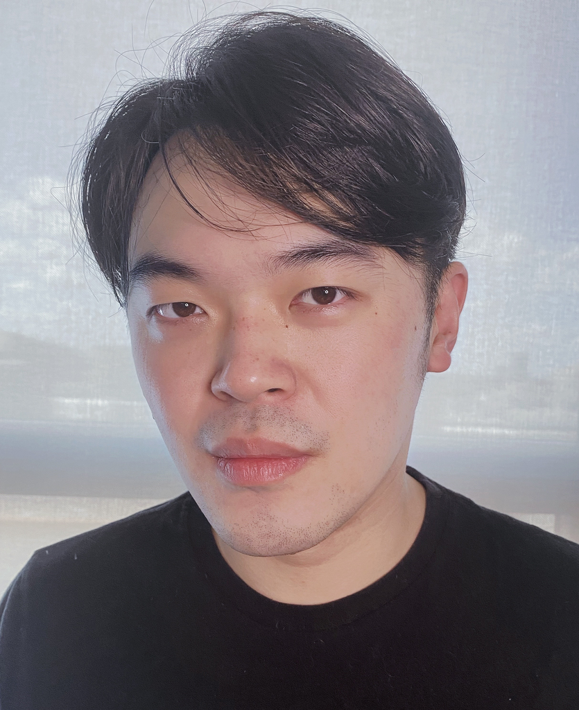

[Department of Finance - LSE](http://www.lse.ac.uk/Finance)  
Houghton Street, London, WC2A 2AE, UK  
Email: r.shi1@lse.ac.uk

I am a PhD Student in Finance at LSE. My research interests are in asset pricing, international finance, and financial economics. I am joining the University of Colorado Boulder (Leeds School of Business) as an Assistant Professor of Finance in the summer of 2022.

[Curriculum Vitae](http://personal.lse.ac.uk/shir1/cv.pdf)

Research

[**A Quantitative Model of Limited Arbitrage in Currency Markets: Theory and Estimation**](http://personal.lse.ac.uk/shir1/JMP.pdf) (Job Market Paper)  
[slides](http://personal.lse.ac.uk/shir1/JMP_slides.pdf)  
I develop and estimate a limits-to-arbitrage model to quantify the effects of financial constraints, arbitrage capital, and hedging demands on asset prices and their deviations from frictionless benchmarks. Using foreign exchange derivatives market data, I find that varying financial constraints and hedging demands contribute to 46 and 35 percent variation in the deviations from covered interest parity of one-year maturities. While arbitrage capital fluctuation explains the remaining 19 percent of variation on average, it periodically stabilizes prices when the other two forces exert disproportionately large impacts. The model features a general form of financial constraints and produces a nonparametric arbitrage profit function. I unveil shapes and dynamics of financial constraints from estimates of this function.

Option-Implied Bounds for the Crash Probability of a Stock (with [Ian Martin](https://personal.lse.ac.uk/martiniw/))  
We propose a framework to compute sharp bounds of the crash probability of an individual stock using option prices. Empirical tests suggest that these bounds are close to the exact forward-looking crash probabilities. They drive out stock characteristics reported in the literature in terms of explaining crash probability variation. Out of sample, either the lower or upper bound outperforms combinations of stock characteristics in terms of forecasting stock-specific crash events. Applying the framework to study the equity of global systemically important banks (G-SIBs) gives rise to forward-looking fragility and stability measures of the global financial system.

[**Model Uncertainty in the Cross Section**](http://personal.lse.ac.uk/shir1/MUCS_Paper.pdf) (with [Jiantao Huang](https://sites.google.com/view/jiantaohuang/home))  
[slides](http://personal.lse.ac.uk/shir1/MUCS_Slides.pdf)  
We develop a transparent Bayesian approach to quantify uncertainty in linear stochastic discount factor (SDF) models. We show that, for a Bayesian decision maker, posterior model probabilities increase with maximum in-sample Sharpe ratios and decrease with model dimensions. Entropy of posterior probabilities represents model uncertainty. We apply our approach to quantify the time series of model uncertainty in North American, European, and Asian Pacific equity markets. Model uncertainty is countercyclical in these markets before the 2008 financial crisis, but remains high afterwards. It predicts investors’ asset allocation decisions across equity and fixed-income funds. In survey data, investors tend to be more pessimistic about equity performance during periods of higher model uncertainty.

[**The Spread of COVID-19 in London: Network Effects and Optimal Lockdowns**](http://personal.lse.ac.uk/shir1/C19LDN_Paper.pdf) (with [Christian Julliard](https://personal.lse.ac.uk/julliard/defaults/Home.html) and [Kathy Yuan](https://personal.lse.ac.uk/yuan/)) revise and resubmit, *Journal of Econometrics*  
[slides](http://personal.lse.ac.uk/shir1/C19LDN_Slides.pdf)  
We generalize a stochastic version of the workhorse SIR (Susceptible-Infectious-Removed) epidemiological model to account for spatial dynamics generated by network interactions. Using the London metropolitan area as a salient case study, we show that commuter network externalities account for about 42% of the propagation of COVID-19. We find that the UK lockdown measure reduced total propagation by 57%, with more than one third of the effect coming from the reduction in network externalities. Counterfactual analyses suggest that: i) the lockdown was somehow late, but further delay would have had more extreme consequences; ii) a targeted lockdown of a small number of highly connected geographic regions would have been equally effective, arguably with significantly lower economic costs; iii) targeted lockdowns based on threshold number of cases are not effective, since they fail to account for network externalities.

Teaching

Fixed Income Markets [Student Evaluation (in person)](http://personal.lse.ac.uk/shir1/FM413_eval.pdf); [Student Evaluation (mixed)](http://personal.lse.ac.uk/shir1/FM413_mixed.pdf); [Student Evaluation (online)](http://personal.lse.ac.uk/shir1/FM413_online.pdf)  
Principles of Finance [Student Evaluation](http://personal.lse.ac.uk/shir1/FM212_eval.pdf)